# Tutorial on Factors using {forcats}

Vebash Naidoo

20/02/2021

# Terminology

To set the stage, let’s talk about the types of data. These are concepts more for beginners, so if you’re familiar with these please feel free to skip ahead.

We have two types of data:

- Numerical data, also known as `Quantitative` data.
- Non-Numerical data, also known as `Qualitative` data (this is what we will be concentrating on in this post).

### Non-Numerical (Qualitative) data

- Also known as **categorical data**, since it can take on some number of distinct categories e.g. eye colour (brown, blue, green, grey etc.), favourite rock band, even names if you think about it, fall under categorical data, albeit many distinct categories may be present in such a `name` variable, and we therefore typically treat those kinds of non-numerical fields as pure character data.
- The categories are limited, and distinct - Siberian cat, Cornish Rex, Russian Blue - and may therefore be *represented* as numbers. In R each distinct category is referred to as a level.
  - For example, you may have a survey question with the following categories:

  | Category | Level Number |
  | --- | --- |
  | Very Likely | 1 |
  | Likely | 2 |
  | Uncertain | 3 |
  | Unlikely | 4 |
  | Very Unlikely | 5 |

  There are 5 levels.
  - Or, you may have a question asking a participant which of your favourite songs they enjoy the most, with the following categories:

  | Category | Level Number |
  | --- | --- |
  | Sweet Child O’ Mine | 1 |
  | Smells Like Teen Spirit | 2 |
  | Hotel California | 3 |
  | Best of You | 4 |
  | Numb | 5 |
  | Unfamiliar with all of these | 6 |

  There are 6 levels.
- The numbers (`Level Number`) are basically placeholders for each category level, and is meant for us to work with it easier in a programming language. If I get the responses:

```
      Numb, Smells Like Teen Spirit, Sweet Child O' Mine, Smells Like Teen Spirit, Numb,
      Smells Like Teen Spirit, Sweet Child O' Mine, Numb, Smells Like Teen Spirit, Numb,
      Sweet Child O' Mine, Sweet Child O' Mine, Smells Like Teen Spirit

      I.e. 5, 2, 1, 2, 5, 2, 1, 5, 2, 5, 1, 1, 2
```

I can’t say *Numb* is 4x better, or 4x worse than *Sweet Child O’ Mine* (in other words, it makes no sense to take Level Number of Numb [5], and subtract Level Number of Sweet Child ’O Mine [1]).

Neither can I say that *Hotel California* is the average category chosen (notice it was not chosen once) but if I take the average of the numerical placeholders for the responses received, I would get 2.62 which is 3 if I round up. In other words, we can’t understand what the “average” song is.

- So we have seen that it does not make sense to do arithmetic on these variables. The distance between the categories is not something that can be measured.
- We **can** count each category, and understand that *Smells Like Teen Spirit* was the most popular among respondents.
- Categorical data may be:
  - Unordered, often refered to merely as Categorical data, or also known as `Nominal` data. For example, if your question is “`What's your favourite Altoids flavour?`” with the following options, while you may rank *Cinnamon* above *Wintergreen* there is no order to these categories! 😁.

  | Fave Flavour | Level Number |
  | --- | --- |
  | Peppermint | 1 |
  | Wintergreen | 2 |
  | Cinnamon | 3 |
  | Spearmint | 4 |
  | Liqourice | 5 |
  | None of these | 6 |

  - Ordered, and hence called `Ordinal` data. Here’s an example using age categories - these are not numerical data, because the `Level Number` is merely a placeholder for the category, and we can’t do arithmetic on these. This is an `Ordinal` variable however, since there is some order to the distinct categories shown in `Age Range`.

  | Age Range | Level Number |
  | --- | --- |
  | Younger than 21 | 1 |
  | 21-30 | 2 |
  | 31-45 | 3 |
  | 46-55 | 4 |
  | Older than 55 | 5 |

# {forcats} 📦

The forcats 📦 is meant to handle `factors` which is R’s data type for categorical data. `forcats` is **for** **cat**egorical data, and is an [anagram](https://r4ds.had.co.nz/factors.html) for `factors` 🆒.

The functions in the package start with `fct_`.

There is non-numeric data where it is useful to work with the data as factors (age-ranges, occupation, etc.), but we must also keep in mind that some non-numeric data should be kept as `character` data.

We’re going to work with non-numeric data that may be treated as factors in this post, and learn how to use the forcats 📦 to make that task easier for us.

## Data

We’re going to use the data from the awesome [TidyTuesday Project](https://github.com/rfordatascience/tidytuesday) ❇️:

- [Beer production data from 2020-03-31](https://github.com/rfordatascience/tidytuesday/tree/master/data/2020/2020-03-31)
- [Beer awards data from 2020-10-20](https://github.com/rfordatascience/tidytuesday/tree/master/data/2020/2020-10-20).

```r
library(tidyverse)
brewing_materials <-
   read_csv(
    # hacky solution to show readers the full path of file
    # str_glue just pastes the various strings next to each other
    str_glue('https://raw.githubusercontent.com/rfordatascience/',
            'tidytuesday/master/data/2020/2020-03-31/',
            'brewing_materials.csv'))
beer_taxed <-
    read_csv(
     str_glue('https://raw.githubusercontent.com/rfordatascience/',
              'tidytuesday/master/data/2020/2020-03-31/',
              'beer_taxed.csv'))
brewer_size <-
    read_csv(
     str_glue('https://raw.githubusercontent.com/rfordatascience/',
     'tidytuesday/master/data/2020/2020-03-31/',
     'brewer_size.csv'))
beer_states <-
    read_csv(
     str_glue('https://raw.githubusercontent.com/rfordatascience/',
     'tidytuesday/master/data/2020/2020-03-31/',
     'beer_states.csv'))
beer_awards <-
    read_csv(
     str_glue('https://raw.githubusercontent.com/rfordatascience/',
     'tidytuesday/master/data/2020/2020-10-20/',
     'beer_awards.csv'))
```

Let’s have a look at the data - here we’re showing a sample from each table.

```r
brewing_materials %>%
  sample_n(50) %>%
  DT::datatable(filter = 'top', list(scrollX = TRUE,
                     pageLength = 5),
    caption = htmltools::tags$caption(
      style = 'caption-side: bottom; text-align: center;',
     'Table Name: ', htmltools::em('Brewing Materials')
  ))
```

|  | data_type | material_type | year | month | type | month_current | month_prior_year | ytd_current | ytd_prior_year |
| --- | --- | --- | --- | --- | --- | --- | --- | --- | --- |
| 1 | Pounds of Materials Used | Grain Products | 2014 | 3 | Malt and malt products | 335350528 | 343473172 | 945861951 | 970896568 |
| 2 | Pounds of Materials Used | Grain Products | 2012 | 6 | Barley and barley products | 17104839 | 14997119 | 60218078 | 50777719 |
| 3 | Pounds of Materials Used | Grain Products | 2010 | 8 | Corn and corn products | 60424525 | 57684547 | 476073574 | 508678313 |
| 4 | Pounds of Materials Used | Non-Grain Products | 2014 | 4 | Hops (dry) | 2167689 | 9833771 | 9588084 | 38412544 |
| 5 | Pounds of Materials Used | Grain Products | 2013 | 6 | Rice and rice products | 64271218 | 59826990 | 380837199 | 356007412 |
| 6 | Pounds of Materials Used | Grain Products | 2009 | 10 | Corn and corn products | 55590153 | 63047343 | 612846280 | 623155259 |
| 7 | Pounds of Materials Used | Non-Grain Products | 2014 | 7 | Hops (used as extracts) | 339167 | 345771 | 2358813 | 2343051 |
| 8 | Pounds of Materials Used | Non-Grain Products | 2015 | 2 | Sugar and syrups | 74138605 | 145936670 |  |  |
| 9 | Pounds of Materials Used | Non-Grain Products | 2014 | 6 | Hops (used as extracts) | 403502 | 339972 | 2019639 | 1997270 |
| 10 | Pounds of Materials Used | Grain Products | 2009 | 7 | Barley and barley products | 4185235 | 3393374 | 33131330 | 33405477 |

[output cut: 40 more lines]

```r
beer_taxed %>%
  head(50) %>%
  DT::datatable(filter = 'top', list(scrollX = TRUE,
                     pageLength = 5),
    caption = htmltools::tags$caption(
      style = 'caption-side: bottom; text-align: center;',
     'Table Name: ', htmltools::em('Beer Taxed')
  ))
```

|  | data_type | tax_status | year | month | type | month_current | month_prior_year | ytd_current | ytd_prior_year | tax_rate |
| --- | --- | --- | --- | --- | --- | --- | --- | --- | --- | --- |
| 1 | Barrels Produced | Totals | 2008 | 1 | Production | 16211480 | 15880125 | 16211480 | 15880125 | $7/$18 per barrel |
| 2 | Barrels Produced | Taxable | 2008 | 1 | In bottles and cans | 13222104 | 12824278 | 13222104 | 12824278 | $7/$18 per barrel |
| 3 | Barrels Produced | Taxable | 2008 | 1 | In barrels and kegs | 1371239 | 1357372 | 1371239 | 1357372 | $7/$18 per barrel |
| 4 | Barrels Produced | Taxable | 2008 | 1 | Tax Determined, Premises Use | 7426 | 8419 | 7426 | 8419 | $7/$18 per barrel |
| 5 | Barrels Produced | Sub Total Taxable | 2008 | 1 | Sub Total Taxable | 14600769 | 14190069 | 14600769 | 14190069 | $7/$18 per barrel |
| 6 | Barrels Produced | Tax Free | 2008 | 1 | For export | 262985 | 268473 | 262985 | 268473 | $7/$18 per barrel |
| 7 | Barrels Produced | Tax Free | 2008 | 1 | For vessels and aircraft | 0 | 0 | 0 | 0 | $7/$18 per barrel |
| 8 | Barrels Produced | Tax Free | 2008 | 1 | Consumed on brewery premises | 708 | 885 | 708 | 885 | $7/$18 per barrel |
| 9 | Barrels Produced | Sub Total Tax-Free | 2008 | 1 | Sub Total Tax-Free | 263693 | 269358 | 263693 | 269358 | $7/$18 per barrel |
| 10 | Barrels Produced | Totals | 2008 | 1 | Total Removals | 14864462 | 14459427 | 14864462 | 14459427 | $7/$18 per barrel |

[output cut: 40 more lines]

```r
brewer_size %>%
  sample_n(50) %>%
  DT::datatable(filter = 'top', list(scrollX = TRUE,
                     pageLength = 5),
    caption = htmltools::tags$caption(
      style = 'caption-side: bottom; text-align: center;',
     'Table Name: ', htmltools::em('Brewer Size')
  ))
```

|  | year | brewer_size | n_of_brewers | total_barrels | taxable_removals | total_shipped |
| --- | --- | --- | --- | --- | --- | --- |
| 1 | 2013 | 1 to 1,000 Barrels | 1923 | 602141.422999999 | 528020.279 | 922 |
| 2 | 2015 | 7,501 to 15,000 Barrels | 133 | 1427754.07 | 1203851.81 | 25574 |
| 3 | 2009 | 7,501 to 15,000 Barrels | 42 | 442753.54 | 388968.45 | 240 |
| 4 | 2013 | 30,001 to 60,000 Barrels | 52 | 2271814.7 | 1909650.87 | 58028 |
| 5 | 2010 | 30,001 to 60,000 Barrels | 38 | 1544051.1 | 1256492.475 | 42409 |
| 6 | 2014 | 6,000,001 Barrels and Over | 15 | 138677888.13 | 127713535.8 | 4331255 |
| 7 | 2017 | 500,001 to 1,000,000 Barrels | 10 | 6253029.02 | 5720117.89 | 94410 |
| 8 | 2019 | 30,001 to 60,000 Barrels | 64 | 2675606.37 | 2906735.837 | 39494 |
| 9 | 2011 | 60,001 to 100,000 Barrels | 16 | 1157839.9 | 1059934.77 | 11701 |
| 10 | 2009 | 100,001 to 500,000 Barrels | 27 | 5422155.72 | 4469288.93 | 128000 |

[output cut: 40 more lines]

```r
beer_states %>%
  sample_n(50) %>%
  DT::datatable(filter = 'top', list(scrollX = TRUE,
                     pageLength = 5),
    caption = htmltools::tags$caption(
      style = 'caption-side: bottom; text-align: center;',
     'Table Name: ', htmltools::em('Beer States')
  ))
```

|  | state | year | barrels | type |
| --- | --- | --- | --- | --- |
| 1 | SC | 2012 | 2904.66 | On Premises |
| 2 | AL | 2009 | 459.88 | Kegs and Barrels |
| 3 | total | 2013 | 18097967.51 | Kegs and Barrels |
| 4 | ID | 2012 | 9112.66 | Bottles and Cans |
| 5 | WY | 2008 | 2135.61 | On Premises |
| 6 | KY | 2019 | 25118.64 | Kegs and Barrels |
| 7 | MO | 2010 | 13289.38 | On Premises |
| 8 | KY | 2012 | 11795.65 | Kegs and Barrels |
| 9 | HI | 2017 | 32067.39 | Kegs and Barrels |
| 10 | WV | 2018 | 7252.5 | On Premises |

[output cut: 40 more lines]

```r
beer_awards %>%
  sample_n(50) %>%
  DT::datatable(filter = 'top', list(scrollX = TRUE,
                     pageLength = 5),
    caption = htmltools::tags$caption(
      style = 'caption-side: bottom; text-align: center;',
     'Table Name: ', htmltools::em('Beer Awards')
  ))
```

|  | medal | beer_name | brewery | city | state | category | year |
| --- | --- | --- | --- | --- | --- | --- | --- |
| 1 | Bronze | Saddle Bronc Brown | Black Tooth Brewing Co. | Sheridan | WY | English-Style Mild Ale | 2019 |
| 2 | Gold | Smoke Creek Rauchbier | Great Basin Brewing Co. | Sparks | NV | Smoke-Flavored Beer | 2006 |
| 3 | Gold | Duckdive Pale Ale | Bills Tavern and Brewhouse | Cannon Beach | OR | American-Style Pale Ale | 2004 |
| 4 | Bronze | Breakside Stay West | Breakside Brewery + Beer Hall | Portland | OR | American-Style Strong Pale Ale | 2017 |
| 5 | Bronze | Chinquapin Butte Golden Ale | Deschutes Brewery | Bend | OR | Gluten Free Beer | 2008 |
| 6 | Gold | Nit Wit | BJ's Restaurant &amp; Brewery | Boulder/Chandler/Clear Lake | CA | Belgian-Style White (or Wit)/Belgian-Style | 2004 |
| 7 | Bronze | Hop Angel I.P.A. | Chelsea Brewing Co. | New York | NY | Cellar or Unfiltered Beer | 2007 |
| 8 | Gold | Speargun | Snake River Brewing Co. | Jackson | WY | Coffee Stout or Porter | 2018 |
| 9 | Bronze | Old Style | Pabst Brewing Co. | San Antonio | TX | American Lager/Ale or Cream Ale | 2003 |
| 10 | Bronze | Mosaic Pale Ale | Random Row Brewing Co. | Charlottesville | VA | Juicy or Hazy Pale Ale | 2020 |

[output cut: 40 more lines]

## Convert variable to factor

To convert a variable to a factor we use `factor()` / `as.factor()` or `forcats::as_factor()`. These functions converts each distinct category to some number placeholder in the background.

Let’s get a better feel for the non-numeric data in the datasets we will be considering here.

### brewing_materials

Let’s have a look at the `material_type` and `type` fields in the brewing_materials dataset.

```r
brewing_materials %>%
  count(material_type)
```

```
## # A tibble: 5 x 2
##   material_type                n
##   <chr>                    <int>
## 1 Grain Products             600
## 2 Non-Grain Products         480
## 3 Total Grain products       120
## 4 Total Non-Grain products   120
## 5 Total Used                 120
```

```r
brewing_materials %>%
  count(type)
```

```
## # A tibble: 12 x 2
##    type                           n
##    <chr>                      <int>
##  1 Barley and barley products   120
##  2 Corn and corn products       120
##  3 Hops (dry)                   120
##  4 Hops (used as extracts)      120
##  5 Malt and malt products       120
##  6 Other                        120
##  7 Rice and rice products       120
##  8 Sugar and syrups             120
##  9 Total Grain products         120
## 10 Total Non-Grain products     120
## 11 Total Used                   120
## 12 Wheat and wheat products     120
```

```r
brewing_materials %>%
  filter(stringr::str_to_lower(material_type) %in%
           c('grain products',
             'non-grain products')) %>%
  count(material_type, type)
```

```
## # A tibble: 9 x 3
##   material_type      type                           n
##   <chr>              <chr>                      <int>
## 1 Grain Products     Barley and barley products   120
## 2 Grain Products     Corn and corn products       120
## 3 Grain Products     Malt and malt products       120
## 4 Grain Products     Rice and rice products       120
## 5 Grain Products     Wheat and wheat products     120
## 6 Non-Grain Products Hops (dry)                   120
## 7 Non-Grain Products Hops (used as extracts)      120
## 8 Non-Grain Products Other                        120
## 9 Non-Grain Products Sugar and syrups             120
```

### factor() / as.factor()

1. These are conversion functions to convert a variable to a factor in Base R.
2. To convert a variable to a factor we may use:
   1. `df <- df %>% mutate(var = factor(var))`
   2. `df <- df %>% mutate(var = as.factor(var))`
3. To figure out what number placeholder a category was given behind the scenes, use `levels()`.
4. The default order of `factor()` is sorted. According to the help page: “The levels of a factor are by default sorted, but the sort order may well depend on the locale at the time of creation, and should not be assumed to be [ASCII](https://theasciicode.com.ar/).”

   ```r
   brewing_materials %>%
     mutate(material_type = factor(material_type)) %>%
     # use dplyr::pull which acts like $ to get the variable
     pull(material_type) %>%
     # let us get the number placeholder attached to each category
     levels()
   ```

   ```
   ## [1] "Grain Products"           "Non-Grain Products"
   ## [3] "Total Grain products"     "Total Non-Grain products"
   ## [5] "Total Used"
   ```

   ```r
   brewing_materials %>%
     mutate(material_type = as.factor(material_type)) %>%
     # can also use count() to count how many in each level
     count(material_type)
   ```

   ```
   ## # A tibble: 5 x 2
   ##   material_type                n
   ##   <fct>                    <int>
   ## 1 Grain Products             600
   ## 2 Non-Grain Products         480
   ## 3 Total Grain products       120
   ## 4 Total Non-Grain products   120
   ## 5 Total Used                 120
   ```

   Notice that the base R functions `factor()` / `as.factor()` created `levels` in the alphabetical sorted order (my locale is ASCII). The output of the first part of the code block shows that `"Grain Products"` was coded as **1**, while `"Total Non-Grain products"` was coded as **4**, and `"Total Used"` was coded as the last level which was **5**.
5. What if I wanted to **specify the levels** myself? I could specify the **levels** in an argument as shown: `levels = c("Level1", ..., "LevelN")`.

   ```r
   brewing_materials %>%
     mutate(material_type = factor(material_type,
                   # I want to make a factor but I want the order to be
                   # as follows:
                   levels = c("Grain Products",
                              "Total Grain products",
                              "Non-Grain Products",
                              "Total Non-Grain products",
                              "Total Used"))) %>%
     pull(material_type) %>%
     levels()
   ```

   ```
   ## [1] "Grain Products"           "Total Grain products"
   ## [3] "Non-Grain Products"       "Total Non-Grain products"
   ## [5] "Total Used"
   ```

   My level specification is used to create the levels, so the numeric encoding follows my specification this time. `"Total Grain products"` is coded as level **2** this time (it was level 3 in the default creation where no `levels` argument was specified).
6. What if I wanted to include levels that may exist in future datasets, but don’t as yet in the dataset we have? This is similar to the `months` example in [R for Data Science](https://r4ds.had.co.nz/factors.html). Let’s try it with adding a *Not Applicable* level, which is not in our dataset’s `material_type` variable.

   ```r
   brewing_materials %>%
     mutate(material_type = factor(material_type,
                             levels = c("Grain Products",
                                        "Total Grain products",
                                        "Non-Grain Products",
                                        "Total Non-Grain products",
                                        "Total Used",
                                        "Not Applicable"))) %>%
     pull(material_type) %>%
     levels()
   ```

   ```
   ## [1] "Grain Products"           "Total Grain products"
   ## [3] "Non-Grain Products"       "Total Non-Grain products"
   ## [5] "Total Used"               "Not Applicable"
   ```

   Has it been created?

   ```r
   brewing_materials %>%
     mutate(material_type = factor(material_type,
                             levels = c("Grain Products",
                                        "Total Grain products",
                                        "Non-Grain Products",
                                        "Total Non-Grain products",
                                        "Total Used",
                                        "Not Applicable"))) %>%
     # we can also count as before but notice that
     # one category that has no data is missing -
     # the artificial `Not Applicable` we added
     count(material_type)
   ```

   ```
   ## # A tibble: 5 x 2
   ##   material_type                n
   ##   <fct>                    <int>
   ## 1 Grain Products             600
   ## 2 Total Grain products       120
   ## 3 Non-Grain Products         480
   ## 4 Total Non-Grain products   120
   ## 5 Total Used                 120
   ```

   A simple `count()` does not quite let us know, but if we add an argument `.drop = FALSE` we get counts for all categories, even those with no observations (i.e. that category has a count of 0). By default the `count()` function drops categories with 0 counts from the output. By adding `.drop = FALSE` we’re asking for these to be included.

   ```r
   brewing_materials %>%
     mutate(material_type = factor(material_type,
                             levels = c("Grain Products",
                                        "Total Grain products",
                                        "Non-Grain Products",
                                        "Total Non-Grain products",
                                        "Total Used",
                                        "Not Applicable"))) %>%
     # we can get all categories by adding the .drop = FALSE
     count(material_type, .drop = FALSE)
   ```

   ```
   ## # A tibble: 6 x 2
   ##   material_type                n
   ##   <fct>                    <int>
   ## 1 Grain Products             600
   ## 2 Total Grain products       120
   ## 3 Non-Grain Products         480
   ## 4 Total Non-Grain products   120
   ## 5 Total Used                 120
   ## 6 Not Applicable               0
   ```

My locale is English South African, and hence is ASCII. The order preference in sorting is: […, !, ", #, …, 0, 1, …, 9, …, A, …, Z, …].

### forcats::as_factor()

`as_factor()` behaves differently to `as.factor()` in that it creates levels in the order in which they appear, hence we get the same factor levels across different locales.

Note the underscore `_` instead of the **`.`**: as**_**factor

#### Base R’s as.factor()

```r
test_factor_var <-  c("012star", "DogsRule", "!this", "%abc",
            "Abc#", "abc$", "$bb", "AreYouKiddingCatsRule!")

test_factor_var %>%
  as.factor() %>%
  print(width = Inf)
```

```
## [1] 012star                DogsRule               !this
## [4] %abc                   Abc#                   abc$
## [7] $bb                    AreYouKiddingCatsRule!
## Levels: !this $bb %abc 012star Abc# abc$ AreYouKiddingCatsRule! DogsRule
```

#### Contrast with forcats::as_factor()

Now let’s consider `as_factor()`.

```r
# here is the raw variable again
test_factor_var
```

```
## [1] "012star"                "DogsRule"               "!this"
## [4] "%abc"                   "Abc#"                   "abc$"
## [7] "$bb"                    "AreYouKiddingCatsRule!"
```

```r
# Now let's make it a factor, this time using
# as_factor()
test_factor_var %>%
  as_factor() %>%
  print(width = Inf)
```

```
## [1] 012star                DogsRule               !this
## [4] %abc                   Abc#                   abc$
## [7] $bb                    AreYouKiddingCatsRule!
## Levels: 012star DogsRule !this %abc Abc# abc$ $bb AreYouKiddingCatsRule!
```

Note that `as_factor()` kept the order as it appears (`Levels: 012star DogsRule ...`), this will be the same for you, even if your locale is different.

#### Convert brewer data

Let’s perform the same conversion we did with Base R functions, but now using `forcats::as_factor()`.

- First let’s have a look at the default order that `as_factor()` creates the variable in.

  ```r
  brewing_materials %>%
    pull(material_type) %>%
    # what order are material_type observations in?
    head(12)
  ```

  ```
  ##  [1] "Grain Products"           "Grain Products"
  ##  [3] "Grain Products"           "Grain Products"
  ##  [5] "Grain Products"           "Total Grain products"
  ##  [7] "Non-Grain Products"       "Non-Grain Products"
  ##  [9] "Non-Grain Products"       "Non-Grain Products"
  ## [11] "Total Non-Grain products" "Total Used"
  ```

  ```r
  brewing_materials %>%
    mutate(material_type = as_factor(material_type)) %>%
    pull(material_type) %>%
    levels()
  ```

  ```
  ## [1] "Grain Products"           "Total Grain products"
  ## [3] "Non-Grain Products"       "Total Non-Grain products"
  ## [5] "Total Used"
  ```

  Notice the levels are created in the order they appear in the `material_type` field - `"Grain Products"` appeared first hence is Level **1**, `"Total Grain products"` appeared second hence occupies Level **2**.

### fct_inorder()

We can also explicitly use the `fct_inorder()` function to reorder the factor levels by first appearance. I add it here just so you’re aware of this option.

For example, the `beer_awards$medal` column would be made alphabetical in my locale if I use as.factor().

```r
beer_awards %>%
  head(3)
```

```
## # A tibble: 3 x 7
##   medal  beer_name      brewery           city      state category          year
##   <chr>  <chr>          <chr>             <chr>     <chr> <chr>            <dbl>
## 1 Gold   Volksbier Vie~ Wibby Brewing     Longmont  CO    American Amber ~  2020
## 2 Silver Oktoberfest    Founders Brewing~ Grand Ra~ MI    American Amber ~  2020
## 3 Bronze Amber Lager    Skipping Rock Be~ Staunton  VA    American Amber ~  2020
```

```r
beer_awards %>%
  mutate(medal = as.factor(medal)) %>%
  pull(medal) %>%
  levels()
```

```
## [1] "Bronze" "Gold"   "Silver"
```

Notice the alphabetical ordering of levels (Bronze, Gold, Silver).

If I follow this with a `fct_inorder()` the ordering of levels is now using the order of appearance instead.

```r
beer_awards %>%
  mutate(medal = as.factor(medal) %>% fct_inorder()) %>%
  pull(medal) %>%
  levels()
```

```
## [1] "Gold"   "Silver" "Bronze"
```

In most cases we’d want this to be Bronze, Silver, Gold in order of increasing award type. We’ll see how to do that just now.

## Manually order levels

### fct_relevel()

- Now we may specify the order ourselves (i.e. manually order the levels) by using `fct_relevel()`. For example, as we talked about previously, we may want the award medals to be ordered Bronze, Silver, Gold in order of increasing award type, instead of order of appearance (or Base R’s alpha sorting in my locale).

  ```r
  beer_awards %>%
    # I want to specify my factor levels myself
    mutate(medal = fct_relevel(medal,
                   # we want a specific order, and
                   # the order in which the categories
                   # appear does not meet that specification
                               "Bronze",
                               "Silver",
                               "Gold")) %>%
    pull(medal) %>%
    levels()
  ```

  ```
  ## [1] "Bronze" "Silver" "Gold"
  ```

- We can’t add a level that is not in the dataset, or we can, but we get a Warning), and the level is not added.

  ```r
  brewing_materials_forcats <- brewing_materials %>%
    # create a factor
    mutate(material_type = as_factor(material_type))

  brewing_materials_forcats %>%
    pull(material_type) %>%
    # what's the default levels?
    levels()
  ```

  ```
  ## [1] "Grain Products"           "Total Grain products"
  ## [3] "Non-Grain Products"       "Total Non-Grain products"
  ## [5] "Total Used"
  ```

  ```r
  brewing_materials_forcats %>%
    # we relevel by specifying the order we want
    mutate(material_type = fct_relevel(material_type,
                                       "Grain Products",
                                       "Non-Grain Products",
                                       "Total Grain products",
                                       "Total Non-Grain products",
                                       "Total Used",
                                       # adding a level that does not exist
                                       "Not Applicable")) %>%
    pull(material_type) %>%
    levels()
  ```

  ```
  ## Warning: Problem with `mutate()` input `material_type`.
  ## i Unknown levels in `f`: Not Applicable
  ## i Input `material_type` is `fct_relevel(...)`.
  ```

  ```
  ## Warning: Unknown levels in `f`: Not Applicable
  ```

  ```
  ## [1] "Grain Products"           "Non-Grain Products"
  ## [3] "Total Grain products"     "Total Non-Grain products"
  ## [5] "Total Used"
  ```

  Notice the warning you get (Warning: Problem with mutate … . We can’t specify a “level” that does not exist in the observations.

  You may have a factor variable that at present has only some of the categories. For example, you may have a month factor variable where the dataset you’re working with only has observations for some months at present. In this case you are going to be specifying the levels yourself so the best is to use the base functions, and specify all months in your `levels` argument despite these not being a part of the values seen in the observations at present.
- The nice part about `fct_relevel()` is you don’t have to list all the categories, sometimes you just want to move one level to the beginning, you may do this as shown below. You may also move some part of the list to a specific position, which may be done using the `after` argument.
  - Say I want to move all the “Total” columns up front:

    ```r
    # Levels at present are:
    brewing_materials_forcats %>%
      pull(material_type) %>%
      levels()
    ```

    ```
    ## [1] "Grain Products"           "Total Grain products"
    ## [3] "Non-Grain Products"       "Total Non-Grain products"
    ## [5] "Total Used"
    ```

    ```r
    brewing_materials_forcats %>%
      # move Total columns to the front of levels
      mutate(material_type = fct_relevel(material_type,
                                         "Total Used",
                                         "Total Grain products",
                                         "Total Non-Grain products")) %>%
      pull(material_type) %>%
      levels()
    ```

    ```
    ## [1] "Total Used"               "Total Grain products"
    ## [3] "Total Non-Grain products" "Grain Products"
    ## [5] "Non-Grain Products"
    ```

    Notice I did not list all categories. The remaining levels will fall behind the “Total” columns in the order they were originally.
  - Say I want to move “Grain Products” to the end. I can specify `after = Inf` to do this.

    ```r
    # Levels at present are:
    brewing_materials_forcats %>%
      pull(material_type) %>%
      levels()
    ```

    ```
    ## [1] "Grain Products"           "Total Grain products"
    ## [3] "Non-Grain Products"       "Total Non-Grain products"
    ## [5] "Total Used"
    ```

    ```r
    brewing_materials_forcats %>%
      # move "Grain Products" to the end of the levels
      mutate(material_type = fct_relevel(material_type,
                                         "Grain Products",
                                         after = Inf)) %>%
      pull(material_type) %>%
      levels()
    ```

    ```
    ## [1] "Total Grain products"     "Non-Grain Products"
    ## [3] "Total Non-Grain products" "Total Used"
    ## [5] "Grain Products"
    ```

  - Say I want to move the “Total Grain products” and “Total Non-Grain products” to after the individual amounts. I again can use the `after` argument to do this. It is easy to get confused as to what integer your `after` should be set as. I think of it as “What position would I like my moved levels to start from”? In this case I want it to start by occupying slot number 3, then slot number 4, so I set `after = 2`, meaning “Please put these moved levels after slot number 2”.

    ```r
    # Levels at present are:
    brewing_materials_forcats %>%
      pull(material_type) %>%
      levels()
    ```

    ```
    ## [1] "Grain Products"           "Total Grain products"
    ## [3] "Non-Grain Products"       "Total Non-Grain products"
    ## [5] "Total Used"
    ```

    ```r
    brewing_materials_forcats %>%
      mutate(material_type = fct_relevel(material_type,
                                         c("Total Grain products",
                                           "Total Non-Grain products"),
                                         # what slot in the levels
                                         # should these go into?
                                         # I want them to start in slot 3
                                         # so I set  after = 2
                                         after = 2)) %>%
      pull(material_type) %>%
      levels()
    ```

    ```
    ## [1] "Grain Products"           "Non-Grain Products"
    ## [3] "Total Grain products"     "Total Non-Grain products"
    ## [5] "Total Used"
    ```

## Collapse multiple levels

### brewer_size

Let’s have a look at the `brewer_size` field in the `brewer_size` dataset.

```r
brewer_size %>%
  count(brewer_size)
```

```
## # A tibble: 16 x 2
##    brewer_size                        n
##    <chr>                          <int>
##  1 1 to 1,000 Barrels                11
##  2 1,000,000 to 6,000,000 Barrels     1
##  3 1,000,001 to 1,999,999 Barrels     9
##  4 1,000,001 to 6,000,000 Barrels     1
##  5 1,001 to 7,500 Barrels            11
##  6 100,001 to 500,000 Barrels        11
##  7 15,001 to 30,000 Barrels          11
##  8 2,000,000 to 6,000,000 Barrels     9
##  9 30,001 to 60,000 Barrels          11
## 10 500,001 to 1,000,000 Barrels      11
## 11 6,000,001 Barrels and Over        11
## 12 60,001 to 100,000 Barrels         11
## 13 7,501 to 15,000 Barrels           11
## 14 Total                             11
## 15 Under 1 Barrel                     6
## 16 Zero Barrels                       1
```

```r
brewer_size %>%
  count(brewer_size,
        # count's default is to consider the number of rows
        # in each group, we can change it using wt (weight)
        # weight in this example is:
        # the number of brewers in each brewer size category,
        # so count will sum up `n_of_brewers` for each category of brewer_size
        wt = n_of_brewers)
```

```
## # A tibble: 16 x 2
##    brewer_size                        n
##    <chr>                          <dbl>
##  1 1 to 1,000 Barrels             27956
##  2 1,000,000 to 6,000,000 Barrels     5
##  3 1,000,001 to 1,999,999 Barrels    45
##  4 1,000,001 to 6,000,000 Barrels     4
##  5 1,001 to 7,500 Barrels          8368
##  6 100,001 to 500,000 Barrels       439
##  7 15,001 to 30,000 Barrels         728
##  8 2,000,000 to 6,000,000 Barrels    47
##  9 30,001 to 60,000 Barrels         556
## 10 500,001 to 1,000,000 Barrels      92
## 11 6,000,001 Barrels and Over       174
## 12 60,001 to 100,000 Barrels        291
## 13 7,501 to 15,000 Barrels         1163
## 14 Total                          41946
## 15 Under 1 Barrel                  1602
## 16 Zero Barrels                     476
```

Notice that the brewer_size variable has a few categories which are slightly different, but which overlap.

| brewer_size |
| --- |
| 1,000,000 to 6,000,000 Barrels |
| 1,000,001 to 6,000,000 Barrels |
| 1,000,001 to 1,999,999 Barrels |
| 2,000,000 to 6,000,000 Barrels |

If you look closely it seems as though *1,000,000 to 6,000,000 Barrels* may be a typo, since *500,001 to 1,000,000 Barrels* is already a category in that year.

It also looks as if *1,000,001 to 6,000,000 Barrels* was split into *1,000,001 to 1,999,999 Barrels* and *2,000,000 to 6,000,000 Barrels* from 2011 onwards.

### fct_collapse()

We can consolidate these levels into one level by using `fct_collapse()`.

```r
# what are the current levels in this variable
brewer_size %>%
  mutate(brewer_size = as_factor(brewer_size)) %>%
  pull(brewer_size) %>%
  levels()
```

```
##  [1] "6,000,001 Barrels and Over"     "1,000,001 to 6,000,000 Barrels"
##  [3] "500,001 to 1,000,000 Barrels"   "100,001 to 500,000 Barrels"
##  [5] "60,001 to 100,000 Barrels"      "30,001 to 60,000 Barrels"
##  [7] "15,001 to 30,000 Barrels"       "7,501 to 15,000 Barrels"
##  [9] "1,001 to 7,500 Barrels"         "1 to 1,000 Barrels"
## [11] "Under 1 Barrel"                 "Total"
## [13] "1,000,000 to 6,000,000 Barrels" "2,000,000 to 6,000,000 Barrels"
## [15] "1,000,001 to 1,999,999 Barrels" "Zero Barrels"
```

```r
brewer_size %>%
  mutate(brewer_size = as_factor(brewer_size)) %>%
  mutate(brewer_size = fct_collapse(brewer_size,
            # the new category name
            "1,000,000 to 6,000,000 Barrels" =
            # the current categories that must become
            # the new category
              c("1,000,000 to 6,000,000 Barrels",
                "1,000,001 to 6,000,000 Barrels",
                "1,000,001 to 1,999,999 Barrels",
                "2,000,000 to 6,000,000 Barrels")
        )) %>%
  pull(brewer_size) %>%
  levels()
```

```
##  [1] "6,000,001 Barrels and Over"     "1,000,000 to 6,000,000 Barrels"
##  [3] "500,001 to 1,000,000 Barrels"   "100,001 to 500,000 Barrels"
##  [5] "60,001 to 100,000 Barrels"      "30,001 to 60,000 Barrels"
##  [7] "15,001 to 30,000 Barrels"       "7,501 to 15,000 Barrels"
##  [9] "1,001 to 7,500 Barrels"         "1 to 1,000 Barrels"
## [11] "Under 1 Barrel"                 "Total"
## [13] "Zero Barrels"
```

Notice that our previous **16** levels are now **13**.

In this case we’d also want to reorder the levels further by using `fct_relevel()`.

```r
brewer_size %>%
  mutate(brewer_size = as_factor(brewer_size)) %>%
  mutate(brewer_size = fct_collapse(brewer_size,
            "1,000,000 to 6,000,000 Barrels" =
              c("1,000,000 to 6,000,000 Barrels",
                "1,000,001 to 6,000,000 Barrels",
                "1,000,001 to 1,999,999 Barrels",
                "2,000,000 to 6,000,000 Barrels")
        )) %>%
  mutate(brewer_size = fct_relevel(brewer_size,
        "Zero Barrels",
        "Under 1 Barrel",
        "1 to 1,000 Barrels",
        "1,001 to 7,500 Barrels",
        "7,501 to 15,000 Barrels",
        "15,001 to 30,000 Barrels",
        "30,001 to 60,000 Barrels",
        "60,001 to 100,000 Barrels",
        "100,001 to 500,000 Barrels",
        "500,001 to 1,000,000 Barrels",
        "1,000,000 to 6,000,000 Barrels",
        "6,000,001 Barrels and Over")) %>%
  pull(brewer_size) %>%
  levels()
```

```
##  [1] "Zero Barrels"                   "Under 1 Barrel"
##  [3] "1 to 1,000 Barrels"             "1,001 to 7,500 Barrels"
##  [5] "7,501 to 15,000 Barrels"        "15,001 to 30,000 Barrels"
##  [7] "30,001 to 60,000 Barrels"       "60,001 to 100,000 Barrels"
##  [9] "100,001 to 500,000 Barrels"     "500,001 to 1,000,000 Barrels"
## [11] "1,000,000 to 6,000,000 Barrels" "6,000,001 Barrels and Over"
## [13] "Total"
```

## Reduce categories

We saw that `fct_collapse()` is used to reduce categories. In the above example, there was some order to the levels so the best we can do is collapse levels into fewer categories, i.e. an `Other` category does not make much sense in the example we used above.

Some times you have way too many levels to visualise, or be useful in considerations, but there isn’t any inherent order in the levels. We will discuss different category reduction strategies for these (i.e. where an `Other` category is a viable option).

### beer_awards

Let’s use the `beer_awards` dataset for this part.

```r
beer_awards %>%
  count(brewery, sort = TRUE) %>%
  DT::datatable()
```

|  | brewery | n |
| --- | --- | --- |
| 1 | Pabst Brewing Co. | 60 |
| 2 | Miller Brewing Co. | 56 |
| 3 | Anheuser-Busch, Inc | 54 |
| 4 | Firestone Walker Brewing Co. | 39 |
| 5 | Alaskan Brewing and Bottling Co. | 32 |
| 6 | Boston Beer Co. | 32 |
| 7 | Coors Brewing Co. | 32 |
| 8 | New Belgium Brewing Co. | 28 |
| 9 | Marin Brewing Co. | 26 |
| 10 | New Glarus Brewing Co. | 26 |

[output cut: 1849 more lines]

```r
beer_awards %>%
  count(category, sort = TRUE) %>%
  DT::datatable()
```

|  | category | n |
| --- | --- | --- |
| 1 | Classic Irish-Style Dry Stout | 62 |
| 2 | American-Style Pale Ale | 61 |
| 3 | Bock | 61 |
| 4 | Robust Porter | 61 |
| 5 | Imperial Stout | 60 |
| 6 | German-Style Pilsener | 59 |
| 7 | German-Style Wheat Ale | 56 |
| 8 | American-Style Amber Lager | 55 |
| 9 | Brown Porter | 55 |
| 10 | Irish-Style Red Ale | 53 |

[output cut: 505 more lines]

```r
beer_awards %>%
  count(city, sort = TRUE) %>%
  DT::datatable()
```

|  | city | n |
| --- | --- | --- |
| 1 | Denver | 145 |
| 2 | Portland | 119 |
| 3 | Milwaukee | 96 |
| 4 | San Diego | 86 |
| 5 | Seattle | 86 |
| 6 | Chicago | 74 |
| 7 | Fort Collins | 72 |
| 8 | San Antonio | 71 |
| 9 | Golden | 69 |
| 10 | Salt Lake City | 68 |

[output cut: 793 more lines]

### fct_other()

We can also collapse levels by grouping together some levels into `Other` using `fct_other()`.

In `fct_other()` we can either:

```
- specify which categories we want to __keep__, where all the rest will be bucketed into the `Other` category.
- specify which categories we want to __drop__ - i.e. which categories do we want to be bucketed into the `Other` category.
```

1. Let’s say that we’re only interested in the *Pilseners* in the `category` variable.

   We can **keep** these Pilseners, and combine all others into a **Non-Pilseners** category using `fct_other()` with the `keep` argument.

   ```r
   beer_awards %>%
     mutate(category = as_factor(category)) %>%
     mutate(category = fct_other(category,
               # which levels do you want to keep?
               keep = c('German-Style Pilsener',
               'Bohemian Style Pilsener',
               'Bohemian-Style Pilsener',
               'European-Style Pilsener',
               'American-Style or International-Style Pilsener',
               'International-Style Pilsener',
               'European Pilsner',
               'European Style Pilsener',
               'American Light Pilsners',
               'American-Style Lager or American-Style Pilsener',
               'American-Style Pilsener',
               'American-Style Pilsener or International-Style Pilsener',
               'American Pilsener',
               'American Pilseners',
               'American Pilsners',
               'American Premium Dark Pilseners',
               'Continental Pilsners',
               'European Classic Pilseners',
               'German Style Pilsener',
               'International Pilsener',
               'Mixed, European Pilsener',
               'American Premium Dark Pilsners',
               'American Premium Pilseners',
               'American Premium Pilsners',
               'Contemporary American-Style Pilsener',
               'Pilsener'),
               # relabel the 'Other' level
               other_level = "Non-Pilseners"
           )) %>%
     pull(category) %>%
     levels()
   ```

   ```
   ##  [1] "American Pilsener"
   ##  [2] "Bohemian-Style Pilsener"
   ##  [3] "German-Style Pilsener"
   ##  [4] "International Pilsener"
   ##  [5] "American-Style Lager or American-Style Pilsener"
   ##  [6] "Contemporary American-Style Pilsener"
   ##  [7] "International-Style Pilsener"
   ##  [8] "American-Style Pilsener"
   ##  [9] "American-Style Pilsener or International-Style Pilsener"
   ## [10] "American-Style or International-Style Pilsener"
   ## [11] "Bohemian Style Pilsener"
   ## [12] "European-Style Pilsener"
   ## [13] "European Style Pilsener"
   ## [14] "German Style Pilsener"
   ## [15] "Pilsener"
   ## [16] "European Pilsner"
   ## [17] "Mixed, European Pilsener"
   ## [18] "European Classic Pilseners"
   ## [19] "American Light Pilsners"
   ## [20] "American Pilsners"
   ## [21] "American Premium Dark Pilsners"
   ## [22] "American Premium Pilsners"
   ## [23] "American Pilseners"
   ## [24] "American Premium Dark Pilseners"
   ## [25] "American Premium Pilseners"
   ## [26] "Continental Pilsners"
   ## [27] "Non-Pilseners"
   ```

   We have successfully kept all Pilseners, and all others have been grouped into the “Non-Pilseners” category.
2. What if we want to keep everything else, and group all Pilseners into a separate category? We can instead use the `drop` argument.

   ```r
       beer_awards %>%
         mutate(category = as_factor(category)) %>%
         mutate(category = fct_other(category,
                   # which levels do you want to drop?
                   drop = c('German-Style Pilsener',
                   'Bohemian Style Pilsener',
                   'Bohemian-Style Pilsener',
                   'European-Style Pilsener',
                   'American-Style or International-Style Pilsener',
                   'International-Style Pilsener',
                   'European Pilsner',
                   'European Style Pilsener',
                   'American Light Pilsners',
                   'American-Style Lager or American-Style Pilsener',
                   'American-Style Pilsener',
                   'American-Style Pilsener or International-Style Pilsener',
                   'American Pilsener',
                   'American Pilseners',
                   'American Pilsners',
                   'American Premium Dark Pilseners',
                   'Continental Pilsners',
                   'European Classic Pilseners',
                   'German Style Pilsener',
                   'International Pilsener',
                   'Mixed, European Pilsener',
                   'American Premium Dark Pilsners',
                   'American Premium Pilseners',
                   'American Premium Pilsners',
                   'Contemporary American-Style Pilsener',
                   'Pilsener'),
                   # relabel the 'Other' level
                   other_level = "Pilseners"
               )) %>%
         pull(category) %>%
         levels() %>%
         as_tibble() %>%
         DT::datatable()
   ```

   |  | value |
   | --- | --- |
   | 1 | American Amber Lager |
   | 2 | American Lager |
   | 3 | American-Belgo-Style Ale |
   | 4 | American-Style Amber/Red Ale |
   | 5 | American-Style Black Ale or American-Style Stout |
   | 6 | American-Style Brown Ale |
   | 7 | American-Style Cream Ale |
   | 8 | American-Style Fruit Beer |
   | 9 | American-Style India Pale Ale |
   | 10 | American-Style Pale Ale |

   [output cut: 480 more lines]

   There are no individual “Pilsener” observations now, instead all Pilseners have been grouped into the “Other” category which we renamed to be “Pilseners”.

### fct_lump()

In the `beer_awards$city` variable we have 803 cities. Say we’re only interested in the top 10 cities represented in the awards.

- We can do this using `fct_lump()` along with the argument `n`.

  ```r
  beer_awards %>%
    mutate(city = as_factor(city)) %>%
    # keep the top 10 cities with the most observations
    # and collapse all other cities into an `Other` category
    mutate(city = fct_lump(city, n = 10)) %>%
    pull(city) %>%
    levels()
  ```

  ```
  ##  [1] "San Antonio"    "Portland"       "Denver"         "Golden"
  ##  [5] "Chicago"        "San Diego"      "Salt Lake City" "Seattle"
  ##  [9] "Milwaukee"      "Fort Collins"   "Other"
  ```

- We can also keep categories with some percentage of the observations using `fct_lump()` along with the argument `prop`.

  ```r
  beer_awards %>%
    mutate(city = as_factor(city)) %>%
    # keep the cities with at least 1.5% of the observations
    # and collapse all other cities into an `Other` category
    mutate(city = fct_lump(city, prop = 0.015,
                           # we can again relabel the 'Other' category
                           other_level = "Rest of the Cities")) %>%
    pull(city) %>%
    levels()
  ```

  ```
  ## [1] "Portland"           "Denver"             "San Diego"
  ## [4] "Seattle"            "Milwaukee"          "Rest of the Cities"
  ```

## Re-labeling levels

Sometimes your factor categories will have long names. You many want to shorten these for graphs etc.

### brewing_materials$type

```r
brewing_materials %>%
  count(type, sort = TRUE)
```

```
## # A tibble: 12 x 2
##    type                           n
##    <chr>                      <int>
##  1 Barley and barley products   120
##  2 Corn and corn products       120
##  3 Hops (dry)                   120
##  4 Hops (used as extracts)      120
##  5 Malt and malt products       120
##  6 Other                        120
##  7 Rice and rice products       120
##  8 Sugar and syrups             120
##  9 Total Grain products         120
## 10 Total Non-Grain products     120
## 11 Total Used                   120
## 12 Wheat and wheat products     120
```

### fct_recode()

The `brewing_materials$type` variable has some long names. Let’s use `fct_recode()` to rename these.

```r
brewing_materials %>%
  mutate(type = as_factor(type)) %>%
  mutate(type = fct_recode(type,
          # "new_name" = "old_name"
          "Barley"     = "Barley and barley products",
          "Malt"       = "Malt and malt products",
          "Rice"       = "Rice and rice products",
          "Corn"       = "Corn and corn products",
          "Wheat"      = "Wheat and wheat products",
          # Notice here I am kinda doing the equivalent of fct_collapse()
          # by assigning 2 categories to new "Hops" category
          "Hops"       = "Hops (dry)",
          "Hops"       = "Hops (used as extracts)"
          )) %>%
  count(type, sort = TRUE)
```

```
## # A tibble: 11 x 2
##    type                         n
##    <fct>                    <int>
##  1 Hops                       240
##  2 Malt                       120
##  3 Corn                       120
##  4 Rice                       120
##  5 Barley                     120
##  6 Wheat                      120
##  7 Total Grain products       120
##  8 Sugar and syrups           120
##  9 Other                      120
## 10 Total Non-Grain products   120
## 11 Total Used                 120
```

## Reorder levels

When visualising data we often want to reorder the levels of our factors. We can use `fct_reorder()`, `fct_reorder2()`, `fct_infreq()` and `fct_rev()` for ordering our factors for visuals.

### fct_infreq() and fct_rev()

`fct_infreq()` orders by the frequency of each category.

Let’s say we were interested in which breweries did the best over time in terms of winning gold medals.

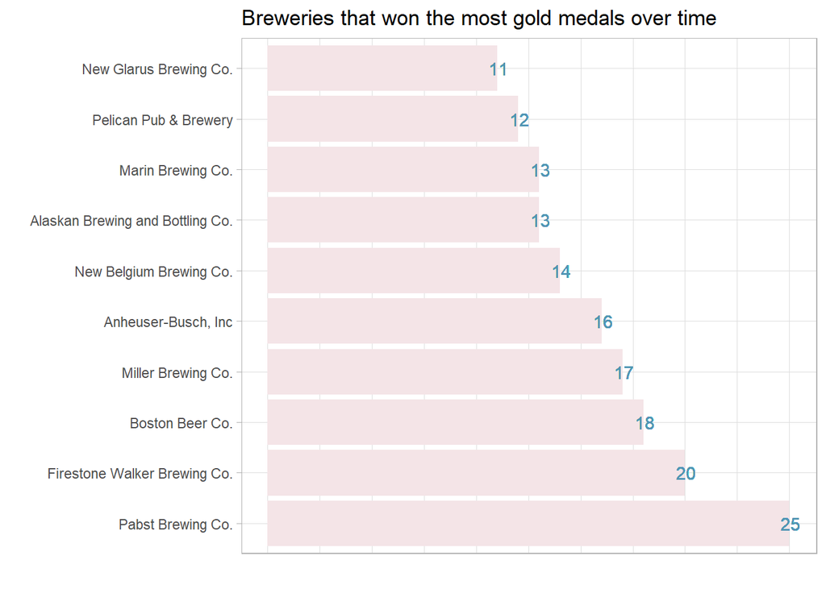

```r
theme_set(theme_light())

beer_awards %>%
  # I only care about Gold medals
  filter(medal == "Gold") %>%
  # I am only interested in top 10 most successful breweries
  mutate(brewery = fct_lump(brewery, n = 10,
                            # if there are ties in 10th and 11th position, keep the first one
                            ties.method = "first")) %>%
  # add a count variable which will be named `n`
  add_count(brewery, medal) %>%
  # remove the Other category since it overwhelms the plot
  filter(brewery != "Other") %>%
  # order the brewery by the frequency in each brewery
  ggplot(aes(y = fct_infreq(brewery))) +
  geom_bar(fill = "#f4e4e7") +
  geom_text(aes(label = as.character(n),
                x = n + .06), hjust = "center",
            colour = "#5196b4") +
  labs(x = "",
       y = "",
       title = "Breweries that won the most gold medals over time") +
  theme(axis.text.x = element_blank(),
        axis.ticks.x = element_blank())
```

The `fct_infreq()` orders it from most frequent (which is shown at bottom of plot, because ggplot plots the levels from the bottom going up) to least frequent (shown at top of plot). Visually we see the least frequent at top of the plot, and most frequent at the bottom of the plot.

To see what `fct_infreq()` does let’s look at the levels.

```r
beer_awards %>%
  filter(medal == "Gold") %>%
  mutate(brewery = fct_lump(brewery, n = 10,
                            ties.method = "first")) %>%
  filter(brewery != "Other") %>%
  mutate(brewery = fct_infreq(brewery)) %>%
  pull(brewery) %>%
  levels()
```

```
##  [1] "Pabst Brewing Co."                "Firestone Walker Brewing Co."
##  [3] "Boston Beer Co."                  "Miller Brewing Co."
##  [5] "Anheuser-Busch, Inc"              "New Belgium Brewing Co."
##  [7] "Alaskan Brewing and Bottling Co." "Marin Brewing Co."
##  [9] "Pelican Pub & Brewery"            "New Glarus Brewing Co."
## [11] "Other"
```

It is sometimes better to see bar plots in descending order on the visual (i.e. we want to see the most frequent at top of plot, and least frequent at the bottom). This can be accomplished by combining `fct_rev()` with `fct_infreq()`.

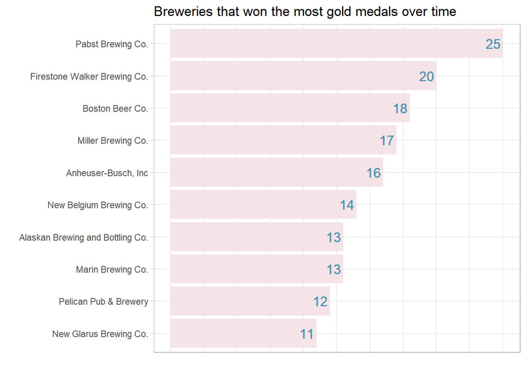

```r
beer_awards %>%
  filter(medal == "Gold") %>%
  mutate(brewery = fct_lump(brewery, n = 10,
                            ties.method = "first")) %>%
  add_count(brewery, medal) %>%
  filter(brewery != "Other") %>%
  # show in decreasing order of winners on plot
  ggplot(aes(y = fct_rev(fct_infreq(brewery)))) +
  geom_bar(fill = "#f4e4e7") +
  geom_text(aes(label = as.character(n),
                x = n + .06), hjust = 1.2,
            colour = "#5196b4",
            size = 4.5,
            position = position_dodge(width = 1)) +
  labs(x = "",
       y = "",
       title = "Breweries that won the most gold medals over time") +
  theme(axis.text.x = element_blank(),
        axis.ticks.x = element_blank())
```

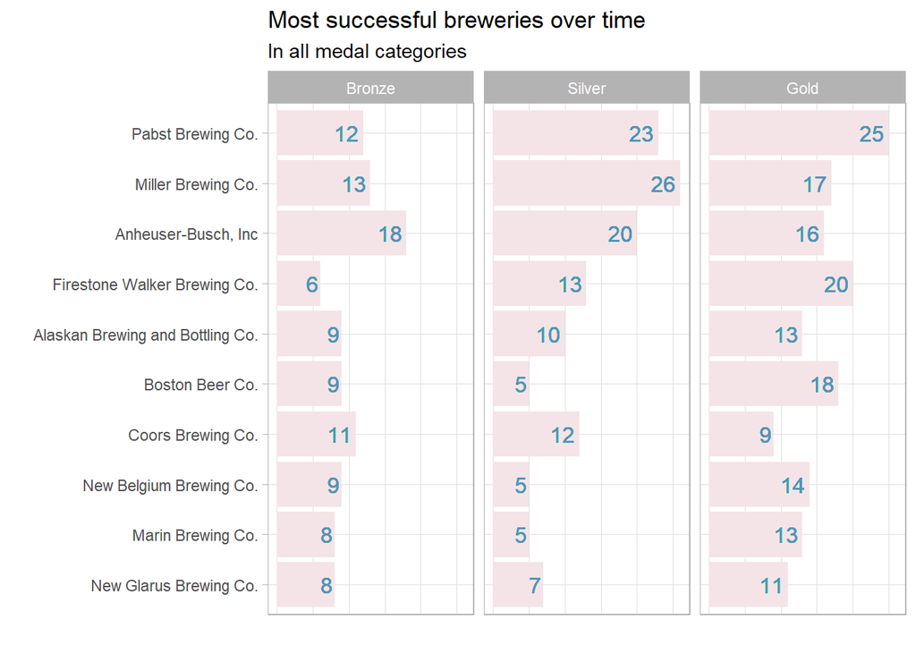

```r
beer_awards %>%
  mutate(brewery = fct_lump(brewery, n = 10)) %>%
  add_count(brewery, medal) %>%
  filter(brewery != "Other") %>%
  ggplot(aes(y = fct_rev(fct_infreq(brewery)))) +
  geom_bar(fill = "#f4e4e7") +
  geom_text(aes(label = as.character(n),
                x = n + .06), hjust = 1.2,
            colour = "#5196b4",
            size = 4.2,
            position = position_dodge(width = 1)) +
  facet_wrap(~ fct_inorder(medal)) +
  labs(x = "",
       y = "",
       title = "Most successful breweries over time",
       subtitle = "In all medal categories") +
  theme(axis.text.x = element_blank(),
        axis.ticks.x = element_blank())
```

### fct_reorder()

On occasion you may want to reorder to make your visuals easier to read. You can do this using `fct_reorder()`.

`fct_reorder(var, some_other_var, some_func)` where:

- var: the variable you want to reorder (below this is the `brewery` variable)
- some_other_var: what should determine the order that var will be put into? Below we’re going to reorder `brewery` by the count of medals the brewery received.
- some_func: Is there some summary function that must be applied? For example, should we sum up some_other_var, or take the median of some_other_var for the order of var to be determined by. Below since we have Bronze, Silver and Gold medals we’re going to sum up the counts in each medal category and use that to determine which order `brewery` should be in.

Ultimately we want to plot the most successful breweries from most successful to least successful in the top 10.

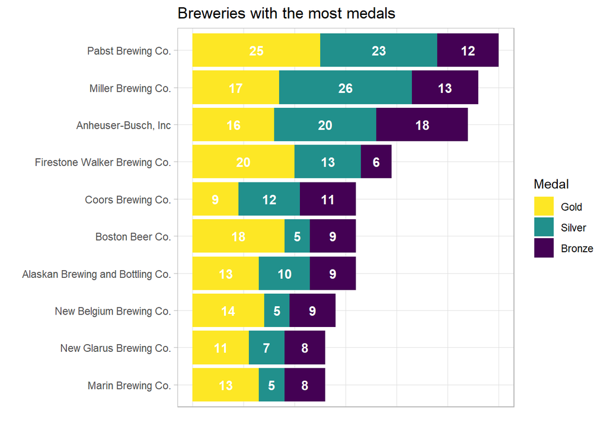

```r
beer_awards %>%
  # keep top 10 breweries, lump all the rest into Other
  mutate(brewery = fct_lump(brewery, n = 10)) %>%
  add_count(brewery, medal) %>%
  select(brewery, medal, n) %>%
  distinct() %>%
  # remove the "Other" category because it makes it hard
  # to see all the rest
  filter(brewery != "Other") %>%
  # reorder the brewery by the sum of the number of all
  # medals such that brewery with most medals are at top
  mutate(brewery = fct_reorder(brewery, n, sum)) %>%
  mutate(medal = fct_relevel(medal,
                                "Bronze",
                                "Silver",
                                "Gold")) %>%
  ggplot(aes(n, brewery,
             fill = medal)) +
  geom_col() +
  geom_text(aes(label = n, fontface = "bold"),
            position = position_stack(vjust = 0.5),
            colour = "white") +
  scale_fill_viridis_d() +
  labs(x = "",
       y = "",
       title = "Breweries with the most medals",
       fill = "Medal") +
  theme(axis.text.x = element_blank(),
        axis.ticks.x = element_blank()) +
  guides(fill = guide_legend(reverse = TRUE))
```

# Further Resources

1. Chapter on [Factors](https://r4ds.had.co.nz/factors.html) in `R for Data Science`.
2. {forcats} [Tidyverse Page](https://forcats.tidyverse.org/).
3. [Vignette on {forcats}](https://forcats.tidyverse.org/articles/forcats.html) by [Emily Robinson](https://twitter.com/robinson_es?lang=en).
4. [David Robinson’s TidyTuesday screencasts](https://www.youtube.com/channel/UCeiiqmVK07qhY-wvg3IZiZQ) often include much factor wrangling.